# anantharam_subramanian_nlp_final_exam

### Name: Anantharam(Ananth) Subramanian

### NLP Final Exam

```python
import numpy
import keras
from tensorflow.keras.datasets import imdb
from tensorflow.keras.models import Sequential
from tensorflow.keras.layers import Dense
from tensorflow.keras.layers import Dropout
from tensorflow.keras.layers import  LSTM as LSTM, SimpleRNN, GRU
#from keras.layers import LSTM , SimpleRNN, GRU
from tensorflow.keras.layers import Embedding
from tensorflow.keras.preprocessing import sequence
from tensorflow.keras.losses import sparse_categorical_crossentropy
```

### Tweets are read from the given csv file

```python
import pandas as pd
data = pd.read_csv("C:\\Users\\anant\\Documents\\NLP\\final_exam\\final.csv")
```

### Few sample tweets along with the sentiment (Neutral, Positive or Negative)

```python
data.head()
```

|  | sentiment | text |
| --- | --- | --- |
| 0 | Neutral | RT @NancyLeeGrahn: How did everyone feel about... |
| 1 | Positive | RT @ScottWalker: Didn't catch the full #GOPdeb... |
| 2 | Neutral | RT @TJMShow: No mention of Tamir Rice and the ... |
| 3 | Positive | RT @RobGeorge: That Carly Fiorina is trending ... |
| 4 | Positive | RT @DanScavino: #GOPDebate w/ @realDonaldTrump... |

### Creating a new column label and defaulting all the values to zero

```python
data['label']=0
```

```python
data.head()
```

|  | sentiment | text | label |
| --- | --- | --- | --- |
| 0 | Neutral | RT @NancyLeeGrahn: How did everyone feel about... | 0 |
| 1 | Positive | RT @ScottWalker: Didn't catch the full #GOPdeb... | 0 |
| 2 | Neutral | RT @TJMShow: No mention of Tamir Rice and the ... | 0 |
| 3 | Positive | RT @RobGeorge: That Carly Fiorina is trending ... | 0 |
| 4 | Positive | RT @DanScavino: #GOPDebate w/ @realDonaldTrump... | 0 |

### If the sentiment is Neutral, the label gets value 2 and if the sentiment is Positive the label is assigned 1

```python
data.loc[data['sentiment']=='Neutral','label']=2
```

```python
data.loc[data['sentiment']=='Positive','label']=1
```

### Since we have 3 different classes (0, 1, 2) for Negative, Positive and Neutral, the target variable label is factorized

```python
from keras.utils import to_categorical
y= to_categorical(data['label'], num_classes=3)
```

### Q1: Create a word dictionary of words to index. Include space for both 'padding' and 'unknown'

### Dictionary is created by using "Collections" (Ref: Spam Classifier methodology notebook). Function below creates both encoding and decoding ie. it assigns index to every common word (encoding) and the common word can be decoded using the index

```python
import collections
def build_dataset(words):
    count = collections.Counter(words).most_common()
    dictionary = dict()
    for word, _ in count:
        dictionary[word] = len(dictionary)
    reverse_dictionary = dict(zip(dictionary.values(), dictionary.keys()))
    return dictionary, reverse_dictionary
```

### Each tweet is then split as words and stored into a word_list

```python
word_list=[]
for i in data['text']:
    word_list = word_list + i.split()
```

```python
len(word_list)
```

```
235029
```

```python
enc, dec = build_dataset(word_list)
```

```python
enc
```

```
{'RT': 0,
 'the': 1,
 '#GOPDebate': 2,
 'to': 3,
 '#GOPDebates': 4,
 'of': 5,
 'a': 6,
 'is': 7,
 'and': 8,
 'I': 9,
 '@RWSurferGirl:': 10,
 'in': 11,
 '🇺🇸': 12,
 'for': 13,
 'on': 14,
 'you': 15,
 'that': 16,
 'Trump': 17,
 'it': 18,
 'about': 19,
 'was': 20,
 '&amp;': 21,
 'not': 22,
 'Fox': 23,
 '@realDonaldTrump': 24,
 'The': 25,
 'this': 26,
 'at': 27,
 'have': 28,
 'from': 29,
 'be': 30,
 'last': 31,
 'are': 32,
 'but': 33,
 'News': 34,
 'with': 35,
 'like': 36,
 'just': 37,
 'me': 38,
 'he': 39,
```

[output cut: 946 more lines]

```
 "we'll": 986,
 'yet': 987,
 '@CNN': 988,
 'proud': 989,
 'out.': 990,
 'Some': 991,
 'Megan': 992,
 'candidate.': 993,
 'free': 994,
 'knew': 995,
 "shouldn't": 996,
 '#trump': 997,
 'China': 998,
 'fuck': 999,
 ...}
```

```python
dec[17]
```

```
'Trump'
```

```python
enc['Trump']
```

```
17
```

```python
for i in enc:
    enc[i] = enc[i]+2

enc['pad']=0
enc['<UNK>'] = 1
dec[-2]= '<UNK>'
dec[-1]='<pad>'
```

```python
enc['Trump']
```

```
19
```

```python
dec[19-2]
```

```
'Trump'
```

```python
enc['Trump']
```

```
19
```

```python
enc
```

```
{'RT': 2,
 'the': 3,
 '#GOPDebate': 4,
 'to': 5,
 '#GOPDebates': 6,
 'of': 7,
 'a': 8,
 'is': 9,
 'and': 10,
 'I': 11,
 '@RWSurferGirl:': 12,
 'in': 13,
 '🇺🇸': 14,
 'for': 15,
 'on': 16,
 'you': 17,
 'that': 18,
 'Trump': 19,
 'it': 20,
 'about': 21,
 'was': 22,
 '&amp;': 23,
 'not': 24,
 'Fox': 25,
 '@realDonaldTrump': 26,
 'The': 27,
 'this': 28,
 'at': 29,
 'have': 30,
 'from': 31,
 'be': 32,
 'last': 33,
 'are': 34,
 'but': 35,
 'News': 36,
 'with': 37,
 'like': 38,
 'just': 39,
 'me': 40,
 'he': 41,
```

[output cut: 946 more lines]

```
 "we'll": 988,
 'yet': 989,
 '@CNN': 990,
 'proud': 991,
 'out.': 992,
 'Some': 993,
 'Megan': 994,
 'candidate.': 995,
 'free': 996,
 'knew': 997,
 "shouldn't": 998,
 '#trump': 999,
 'China': 1000,
 'fuck': 1001,
 ...}
```

### Q2. Create a character index of characters to index. Explain WHY or WHY NOT you would include an "unknown" index (Look at your dictionary for this)

```python
chars = []
for i in data['text']:
    chars = chars+list(i)
```

```python
from collections import Counter

f= Counter(chars)
```

```python
f.most_common()
```

```
[(' ', 223579),
 ('e', 140036),
 ('t', 106711),
 ('a', 93539),
 ('o', 76702),
 ('i', 66303),
 ('n', 65948),
 ('s', 64543),
 ('r', 61717),
 ('h', 46854),
 ('l', 44837),
 ('d', 35894),
 ('u', 32895),
 ('b', 30766),
 ('c', 28161),
 ('m', 26989),
 ('p', 25019),
 ('#', 21730),
 ('g', 21283),
 ('y', 20289),
 ('G', 20251),
 ('D', 19126),
 ('O', 18879),
 ('P', 18623),
 ('w', 17702),
 ('.', 17621),
 ('T', 17575),
 ('f', 16756),
 ('R', 14460),
 ('@', 14178),
 (':', 13538),
 ('k', 12210),
 ('/', 11598),
 ('v', 8618),
 ('S', 7626),
 ('I', 6954),
 ('W', 6618),
 ('C', 6510),
 ("'", 5657),
 (',', 5164),
```

[output cut: 188 more lines]

```
 ('💰', 1),
 ('💸', 1),
 ('🚷', 1),
 ('🚺', 1),
 ('🔫', 1),
 ('🍔', 1),
 ('💣', 1),
 ('🛃', 1),
 ('🚧', 1),
 ('🚔', 1),
 ('👀', 1),
 ('î', 1),
 ('ł', 1),
 ('é', 1),
 ('à', 1)]
```

### Well, looking into the characters spitted (cell above), there are characters like \U000fe320, ł, \xa0, etc. These need to be flagged unknown.

### I have removed those unknown characters from the dictionary so whenever these characters are encountered, the value assigned to unknown will be assigned.

```python
itmsToRemove = ['🏼','''\xa0''','''\U000fe327''','''\U000fe320''','ł','''\U000fe4ec''','''\U000fe4e6''','''\xa0''','''\n''']
for i in itmsToRemove:
    for c in range(chars.count(i)):
        chars.remove(i)
```

### Similar to words, a character dictionary is created using a similar function

```python
import collections
def build_charset(chars):
    count = collections.Counter(chars).most_common()
    f= Counter(chars)
    f.most_common()
    dictionary = dict()
    for char, _ in count:
        dictionary[char] = len(dictionary)
    reverse_dictionary = dict(zip(dictionary.values(), dictionary.keys()))
    return dictionary, reverse_dictionary
```

```python
enc1, dec1 = build_charset(chars)
```

```python
enc1
```

```
{' ': 0,
 'e': 1,
 't': 2,
 'a': 3,
 'o': 4,
 'i': 5,
 'n': 6,
 's': 7,
 'r': 8,
 'h': 9,
 'l': 10,
 'd': 11,
 'u': 12,
 'b': 13,
 'c': 14,
 'm': 15,
 'p': 16,
 '#': 17,
 'g': 18,
 'y': 19,
 'G': 20,
 'D': 21,
 'O': 22,
 'P': 23,
 'w': 24,
 '.': 25,
 'T': 26,
 'f': 27,
 'R': 28,
 '@': 29,
 ':': 30,
 'k': 31,
 '/': 32,
 'v': 33,
 'S': 34,
 'I': 35,
 'W': 36,
 'C': 37,
 "'": 38,
 ',': 39,
```

[output cut: 180 more lines]

```
 '👺': 220,
 '💰': 221,
 '💸': 222,
 '🚷': 223,
 '🚺': 224,
 '🔫': 225,
 '🍔': 226,
 '💣': 227,
 '🛃': 228,
 '🚧': 229,
 '🚔': 230,
 '👀': 231,
 'î': 232,
 'é': 233,
 'à': 234}
```

### Now the adjustments are done for the padding and unknown

```python
for i in enc1:
    enc1[i] = enc1[i]+2

enc1['pad']=0
enc1['<UNK>'] = 1
dec1[-2]= '<UNK>'
dec1[-1]='<pad>'
```

```python
enc1
```

```
{' ': 2,
 'e': 3,
 't': 4,
 'a': 5,
 'o': 6,
 'i': 7,
 'n': 8,
 's': 9,
 'r': 10,
 'h': 11,
 'l': 12,
 'd': 13,
 'u': 14,
 'b': 15,
 'c': 16,
 'm': 17,
 'p': 18,
 '#': 19,
 'g': 20,
 'y': 21,
 'G': 22,
 'D': 23,
 'O': 24,
 'P': 25,
 'w': 26,
 '.': 27,
 'T': 28,
 'f': 29,
 'R': 30,
 '@': 31,
 ':': 32,
 'k': 33,
 '/': 34,
 'v': 35,
 'S': 36,
 'I': 37,
 'W': 38,
 'C': 39,
 "'": 40,
 ',': 41,
```

[output cut: 182 more lines]

```
 '💸': 224,
 '🚷': 225,
 '🚺': 226,
 '🔫': 227,
 '🍔': 228,
 '💣': 229,
 '🛃': 230,
 '🚧': 231,
 '🚔': 232,
 '👀': 233,
 'î': 234,
 'é': 235,
 'à': 236,
 'pad': 0,
 '<UNK>': 1}
```

```python
enc1['🐘']
```

```
114
```

```python
dec1[114-2]
```

```
'🐘'
```

### Q3. Demonstrate that you can encode (to a number sequence) and decode (from numbers back to text) a tweet using both words and single characters

## I have chosen one of the tweets to demonstrate encoding and decoding

```python
text1 = data.iloc[0,1]
```

```python
text1
```

```
'RT @NancyLeeGrahn: How did everyone feel about the Climate Change question last night? Exactly. #GOPDebate'
```

## The cell below shows the demo for encoding and decoding words in a tweet.

```python
print(text1)
encoding_demo = []
for word in text1.split():
    if(word in enc.keys()):
        encoding_demo.append(enc[word])
    else:
        encoding_demo.append(enc['<UNK>'])


print(encoding_demo)

decoding_demo = []
for i in encoding_demo:
    decoding_demo.append(dec[i-2])


print(decoding_demo)
```

```
RT @NancyLeeGrahn: How did everyone feel about the Climate Change question last night? Exactly. #GOPDebate
[2, 2951, 165, 102, 445, 468, 21, 3, 1298, 2396, 226, 33, 498, 6863, 4]
['RT', '@NancyLeeGrahn:', 'How', 'did', 'everyone', 'feel', 'about', 'the', 'Climate', 'Change', 'question', 'last', 'night?', 'Exactly.', '#GOPDebate']
```

```python
text2 = data.iloc[1585,1]
text2
```

```
'The human embodiment of ¯\\_(ツ)_/¯ #GOPDebate http://t.co/rUkXAyZMbu'
```

```python
text3 = list(text2)
text3
```

```
['T',
 'h',
 'e',
 ' ',
 'h',
 'u',
 'm',
 'a',
 'n',
 ' ',
 'e',
 'm',
 'b',
 'o',
 'd',
 'i',
 'm',
 'e',
 'n',
 't',
 ' ',
 'o',
 'f',
 ' ',
 '¯',
 '\\',
 '_',
 '(',
 'ツ',
 ')',
 '_',
 '/',
 '¯',
 ' ',
 '#',
 'G',
 'O',
 'P',
 'D',
 'e',
```

[output cut: 12 more lines]

```
 't',
 '.',
 'c',
 'o',
 '/',
 'r',
 'U',
 'k',
 'X',
 'A',
 'y',
 'Z',
 'M',
 'b',
 'u']
```

### The cell below shows an example for encoding and decoding of characters

```python
print(list(text2))
encoding_demo_char = []
for text in list(text2):
    if(text in enc1.keys()):
        encoding_demo_char.append(enc1[text])
    else:
        encoding_demo_char.append(enc1['<UNK>'])


print(encoding_demo_char)

decoding_demo_char = []
for i in encoding_demo_char:
    decoding_demo_char.append(dec1[i-2])


print(decoding_demo_char)
```

```
['T', 'h', 'e', ' ', 'h', 'u', 'm', 'a', 'n', ' ', 'e', 'm', 'b', 'o', 'd', 'i', 'm', 'e', 'n', 't', ' ', 'o', 'f', ' ', '¯', '\\', '_', '(', 'ツ', ')', '_', '/', '¯', ' ', '#', 'G', 'O', 'P', 'D', 'e', 'b', 'a', 't', 'e', ' ', 'h', 't', 't', 'p', ':', '/', '/', 't', '.', 'c', 'o', '/', 'r', 'U', 'k'…
[28, 11, 3, 2, 11, 14, 17, 5, 8, 2, 3, 17, 15, 6, 13, 7, 17, 3, 8, 4, 2, 6, 29, 2, 130, 155, 81, 84, 156, 82, 81, 34, 130, 2, 19, 22, 24, 25, 23, 3, 15, 5, 4, 3, 2, 11, 4, 4, 18, 32, 34, 34, 4, 27, 16, 6, 34, 10, 60, 33, 75, 42, 21, 79, 46, 15, 14]
['T', 'h', 'e', ' ', 'h', 'u', 'm', 'a', 'n', ' ', 'e', 'm', 'b', 'o', 'd', 'i', 'm', 'e', 'n', 't', ' ', 'o', 'f', ' ', '¯', '\\', '_', '(', 'ツ', ')', '_', '/', '¯', ' ', '#', 'G', 'O', 'P', 'D', 'e', 'b', 'a', 't', 'e', ' ', 'h', 't', 't', 'p', ':', '/', '/', 't', '.', 'c', 'o', '/', 'r', 'U', 'k'…
```

### Q4. What sequence length would you choose if asked to provide a model based on words. How did you determine this?

### Ans. Input length is one of the parameters that is needed within the Embedding Layer of the NN (ex. LSTM). We need to provide padding to cover for the extra lengths based on the sequence length. Let us say the input length is 100 and this particular sequence of words is of length 80. The padding covers for the 20 spaces to cover for the maximum input length which is 100. For this particular scenario, an array of list is created with the tweet dataset after passing it through the encoding function.

```python
import numpy as np
X1 = []
X1 = np.asarray([np.asarray([enc.get(g,2) for g in txt.split()]) for txt in data['text']])
```

```python
max_length1 = []
for i in X1:
    max_length1.append(len(i))
```

### Max word length among the tweets is 29.

```python
max(max_length1)
```

```
29
```

```python
count = {}
for i in max_length1:
    if(i in count.keys()):
        count[i] = count[i]+1
    else:
        count[i] = 1

sum(count.values())
```

```
13871
```

## The bar graph below describes the spread of tweets by their length

```
<BarContainer object of 28 artists>
```

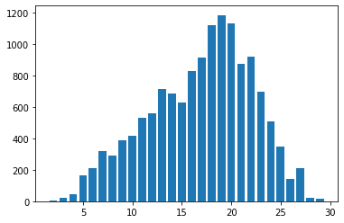

```python
plt.bar(x=count.keys(), height = count.values())
```

### So I would choose the sequence length as 30 for a model based on words ( allowing for 1 padding for the tweets with maximum words)

### Q5. What sequence length would you choose if asked to provide a model based on characters. How did you determine this?

### The methodology followed for words is repeated for characters.

```python
import numpy as np
X = []
X = np.asarray([np.asarray([enc1.get(chr,2) for chr in txt]) for txt in data['text']])
```

```python
X[1585]
```

```
array([ 28,  11,   3,   2,  11,  14,  17,   5,   8,   2,   3,  17,  15,
         6,  13,   7,  17,   3,   8,   4,   2,   6,  29,   2, 130, 155,
        81,  84, 156,  82,  81,  34, 130,   2,  19,  22,  24,  25,  23,
         3,  15,   5,   4,   3,   2,  11,   4,   4,  18,  32,  34,  34,
         4,  27,  16,   6,  34,  10,  60,  33,  75,  42,  21,  79,  46,
        15,  14])
```

```python
from sklearn.model_selection import train_test_split
X_train, X_test, y_train, y_test = train_test_split(X, y, test_size=0.25, random_state=42)
```

```python
max_length = []
for i in X:
    max_length.append(len(i))
```

```python
max(max_length)
```

```
153
```

```python
count1 = {}
for i in max_length:
    if(i in count1.keys()):
        count1[i] = count1[i]+1
    else:
        count1[i] = 1

sum(count1.values())
```

```
13871
```

### The graph below shows the spread of the number of characters in the tweets

```
<BarContainer object of 134 artists>
```

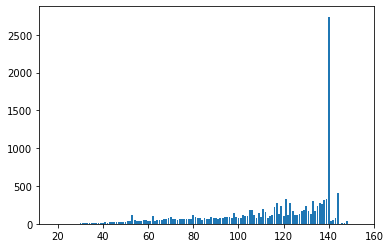

```python
plt.bar(x=count1.keys(), height = count1.values())
```

### The sequence length that I would use for a model based on characters is 154 (allowing for 1 padding for the tweets with maximum characters)

```python
max_char_length = 154
X_train = sequence.pad_sequences(X_train, maxlen=max_char_length)
X_test = sequence.pad_sequences(X_test, maxlen=max_char_length)
```

```python
X_train[10]
```

```
array([ 0,  0,  0,  0,  0,  0,  0,  0,  0,  0,  0,  0,  0,  0,  0,  0,  0,
        0,  0,  0,  0,  0,  0,  0,  0,  0,  0,  0,  0,  0,  0,  0,  0,  0,
        0,  0,  0,  0,  0,  0,  0,  0,  0,  0,  0,  0,  0,  0,  0,  0,  0,
        0,  0,  0,  0,  0,  0,  0,  0,  0,  0,  0,  0, 42, 12,  9,  6,  2,
       26, 11, 21,  2, 13,  7, 13,  2, 21,  5, 40, 12, 12,  2, 15,  5, 16,
       33, 26,  5, 10, 13,  2,  5,  9,  9,  2, 46, 43, 40,  9,  2,  6,  8,
       12, 21,  2,  5,  9, 33,  2,  4, 11,  3,  2, 17,  6, 13,  3, 10,  5,
        4,  3,  9,  2,  5, 15,  6, 14,  4,  2,  9,  6, 16,  7,  5, 12,  2,
        7,  9,  9, 14,  3,  9,  2, 19, 22, 24, 25, 23,  3, 15,  5,  4,  3,
        9])
```

```python
type(X_train)
```

```
numpy.ndarray
```

```python
import datetime
import time
import tensorflow as tf
log_dir="C:\\Users\\anant\\Documents\\NLP\\final_exam\\logs\\fit\\" + datetime.datetime.now().strftime("%Y%m%d-%H%M%S")
tensorboard_callback = tf.keras.callbacks.TensorBoard(log_dir=log_dir, profile_batch= 0, histogram_freq=1)
```

### Q6. Build and train a model using character sequences. Send your model to rslater@smu.edu (Probably to big to submit to 2DS)

### An LSTM model is defined with drop-out (as it is understood LSTM likes drop-outs). The saved model has been mailed to rslater@smu.edu

```python
top_chars=253
embedding_vector_length = 300
model= Sequential()
model.add(Embedding(top_chars, embedding_vector_length,input_length=max_char_length))
model.add(LSTM(150))
model.add(Dropout(0.4))
model.add(Dense(3, activation='softmax'))
model.compile(loss='categorical_crossentropy', optimizer='adam', metrics=['accuracy'])
print(model.summary())
model.fit(X_train, y_train, validation_data=(X_test, y_test), epochs=30, batch_size=500,callbacks=[tensorboard_callback])
model.save_weights('C:\\Users\\anant\\Documents\\NLP\\final_exam\\ananth_sub.h5')
```

```
Model: "sequential_6"
_________________________________________________________________
Layer (type)                 Output Shape              Param #
=================================================================
embedding_6 (Embedding)      (None, 154, 300)          75900
_________________________________________________________________
lstm_6 (LSTM)                (None, 150)               270600
_________________________________________________________________
dropout_6 (Dropout)          (None, 150)               0
_________________________________________________________________
dense_6 (Dense)              (None, 3)                 453
=================================================================
Total params: 346,953
Trainable params: 346,953
Non-trainable params: 0
_________________________________________________________________
None
Train on 10403 samples, validate on 3468 samples
```

```python
scores = model.evaluate(X_test,y_test,verbose=0)
```

```python
print('Accuracy: %.2f%%' % (scores[1]*100))
```

```
Accuracy: 63.70%
```

### Q7. What is the vector you learned for the elephant emoji

### The second layer weights is first created and then we pass the index for elephant emoji which is 114

```python
second_layer_weights = model.layers[0].get_weights()[0]
```

### Here is the vector learned for elephant emoji

```python
second_layer_weights[114]
```

```
array([-8.72784108e-02,  1.42484531e-01,  1.36334166e-01,  1.88603610e-01,
       -1.48405477e-01,  1.72544345e-01,  1.71210885e-01, -7.77512044e-02,
       -2.04729155e-01, -1.12406395e-01, -1.83338627e-01, -1.51812509e-01,
       -1.85648546e-01, -5.88362990e-03, -2.65334416e-02,  1.00644499e-01,
       -4.74442206e-02,  1.69205979e-01,  6.74925819e-02, -1.17769413e-01,
        1.97352961e-01, -1.47885144e-01,  1.97080672e-01,  1.74597740e-01,
        9.84378979e-02, -1.33647680e-01, -1.39802948e-01, -1.22670889e-01,
        1.24363296e-01,  4.79582436e-02,  1.88611329e-01,  3.26329470e-02,
        1.26074962e-02,  9.59419757e-02, -1.71936393e-01, -1.41640469e-01,
       -7.63409734e-02,  1.16953507e-01, -1.65056050e-01, -1.18679747e-01,
       -4.24504094e-03, -1.31950349e-01,  1.37554929e-01,  1.30668581e-01,
        1.58006698e-01, -5.69822155e-02, -5.51585890e-02,  2.00362265e-01,
        2.73531838e-03,  1.38096288e-01,  1.50101855e-01,  1.33848354e-01,
        2.64734365e-02, -1.98098533e-02, -6.74825311e-02,  9.48954597e-02,
       -1.82932556e-01, -1.42970324e-01, -1.23700865e-01, -1.47105902e-01,
       -2.21508309e-01, -1.71141446e-01,  1.50645182e-01,  1.31084993e-01,
        1.60594419e-01, -1.25654474e-01, -1.42384708e-01, -5.71587309e-02,
        3.30270231e-02, -7.06185699e-02,  1.38528034e-01,  1.44639939e-01,
        7.71173537e-02, -1.37574196e-01, -1.76247731e-01,  1.17026903e-01,
       -1.51777297e-01,  1.73301741e-01, -1.58269539e-01, -9.42385420e-02,
       -1.43529534e-01, -8.90312269e-02,  1.46587685e-01, -1.67993873e-01,
       -8.18224847e-02, -1.69529662e-01,  4.72731180e-02, -1.13878489e-01,
        6.96081370e-02,  9.82047319e-02,  1.97416127e-01, -1.57217383e-01,
        1.60391152e-01, -7.28946850e-02, -7.44150579e-02, -8.29485953e-02,
       -1.03318311e-01, -8.00530985e-02, -8.65123644e-02,  6.85569830e-05,
       -2.53161248e-02,  1.26948908e-01, -1.52877361e-01, -1.91659346e-01,
       -5.47231063e-02, -1.57495841e-01, -3.75329182e-02,  1.01823404e-01,
       -1.21144615e-01,  1.45921275e-01, -1.48481935e-01,  1.09380014e-01,
        7.23438263e-02,  8.05367976e-02,  9.55526456e-02,  1.01056419e-01,
        1.45393595e-01,  1.76921383e-01,  1.70208693e-01, -1.30829677e-01,
        1.19159095e-01,  2.09588930e-01,  1.21875301e-01, -1.69865027e-01,
        1.27546638e-01,  5.85437492e-02, -3.25492695e-02,  1.13380775e-01,
        1.68306485e-01,  1.45201892e-01,  9.47111100e-02,  1.66046694e-01,
        7.28734732e-02,  4.17098664e-02,  6.01135902e-02, -1.38004690e-01,
        1.01756513e-01, -1.73270628e-01, -1.23859741e-01,  1.07404783e-01,
       -1.59405231e-01, -1.20450594e-01,  9.61952507e-02, -4.51992974e-02,
        1.37895435e-01, -1.13090895e-01, -1.19868092e-01, -1.54049650e-01,
       -9.16137770e-02, -1.66776791e-01,  7.21340030e-02,  1.15782201e-01,
       -3.74100953e-02,  1.15867801e-01,  1.55713513e-01, -1.24795265e-01,
       -1.89556181e-01,  9.70689207e-02,  1.79612577e-01,  1.25134096e-01,
```

[output cut: 21 more lines]

```
        8.82558897e-02, -1.39542744e-01,  1.31802708e-01, -1.06464587e-01,
       -1.28633901e-01,  1.46727890e-01,  1.08197398e-01, -2.56882366e-02,
        7.46851554e-03,  1.17989682e-01, -1.07587151e-01,  6.43427148e-02,
        1.71272442e-01,  1.04724646e-01,  6.08634800e-02, -8.36273059e-02,
        1.82196677e-01,  2.07029447e-01,  2.03835830e-01, -1.30871415e-01,
        1.69137537e-01,  2.03824252e-01, -1.04402870e-01, -1.02993272e-01,
       -8.99478793e-02, -1.19023420e-01, -1.32313430e-01,  1.33932471e-01,
        7.62061998e-02, -1.85404956e-01,  1.82847902e-01,  2.23104730e-01,
        1.52716830e-01, -1.75428078e-01, -1.76948890e-01, -8.42556134e-02,
       -8.40904117e-02, -1.75891235e-01,  2.02902913e-01,  1.39315516e-01,
       -1.21207930e-01,  4.81600836e-02, -9.73613858e-02,  1.12948567e-01,
        1.69115186e-01,  9.58628058e-02,  1.06153958e-01, -3.05929920e-03,
        1.59074828e-01,  1.31039485e-01, -1.40864879e-01, -5.77365840e-03,
       -1.74013481e-01, -8.17543641e-02, -7.28986338e-02,  8.60651210e-03],
      dtype=float32)
```